# MATH-23C PROJECT - Analysis of /r/ForeverAlone Dataset

by Indri N. Himawan

First, let’s load up this data onto R and load up the right libraries.

```r
library("fitdistrplus")
library("stringr")
library("stats4")
library("e1071")
library("ggplot2")

ForeverAlone <- read.csv("lib/foreveralone.csv")
```

# Income and Suicide

I want to see how many people in this subreddit has/n’t attempted suicide depending on their income. In other words, does income level affect likelihood of suicide?

## Income and Suicide: using stacked barplot

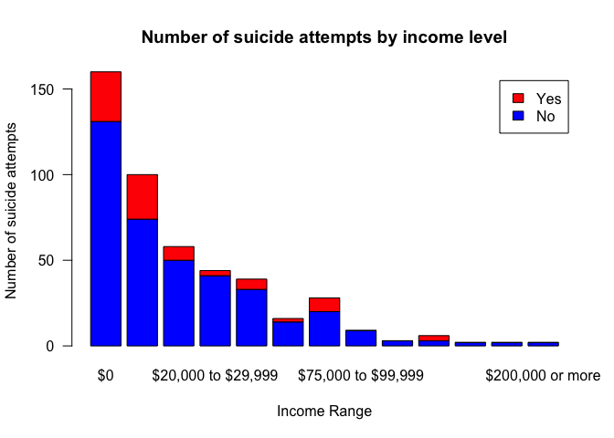

```r
count <- table(ForeverAlone$attempt_suicide, ForeverAlone$income)
orderedCount <- count[,c(1,2,3,8,10,11,12,13,4,5,6,7,9)]
barplot(orderedCount, main = "Number of suicide attempts by income level",
        xlab = "Income Range",
        ylab = "Number of suicide attempts",
        legend.text = TRUE,
        las = 1,
        col = c("blue", "red"))
```

## Income and Suicide: Logical Regression

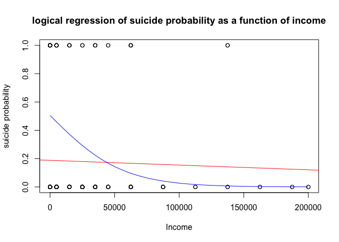

```r
# helper function
findAverage <- function(row){
  incomeRange <- row[5]
  cleanRange <- str_remove_all(incomeRange, "[$,A-z]")
  nums <- as.numeric(strsplit(cleanRange, "\\s+")[[1]])
  if (length(nums) == 1){
    nums[1]
  } else {
    sum(nums)/length(nums)
  }
}

ForeverAlone$incomeAverage <- apply(ForeverAlone, 1, findAverage)
attemptedSuicide <- (as.numeric(ForeverAlone$attempt_suicide=="Yes")); head(attemptedSuicide)

income <- ForeverAlone$incomeAverage
plot(income, attemptedSuicide, xlab = "Income", ylab="suicide probability", main = "logical regression of suicide probability as a function of income")
b <- cov(income, attemptedSuicide)/var(income)
a <- mean(attemptedSuicide) - b*mean(income);a
abline(a, b, col = "red")

MLL<- function(alpha, beta) {
  -sum( log( exp(alpha+beta*income)/(1+exp(alpha+beta*income)) )*attemptedSuicide +
          log(1/(1+exp(alpha+beta*income)))*(1-attemptedSuicide) )
}

results<-mle(MLL, start = list(alpha = 0, beta = 0)) #an initial guess is required
results@coef
curve( exp(results@coef[1]+results@coef[2]*x)/ (1+exp(results@coef[1]+results@coef[2]*x)),col = "blue", add=TRUE)
```

```r
# test for all the income values to see if it is a good model
uniqueIncomes <- sort(unique(income))
#  [1]      0.0   5000.5  14999.5  24999.5  34999.5  44999.5  62499.5  87499.5 112499.5 137499.5
# [11] 162499.5 187499.0 200000.0

findMean <- function (incomeToEvaluate) {
  index <- which(income == incomeToEvaluate); head(index)
  mean(attemptedSuicide[index])   #20%
}

res <- lapply(uniqueIncomes, findMean)
cleanRes <- numeric(length(res))
for (idx in 1: length(res)) {
  cleanRes[idx] = res[[idx]]
}

cleanRes
 # [1] 0.18125000 0.26000000 0.13793103 0.06818182 0.15384615 0.12500000 0.28571429 0.00000000
 # [9] 0.00000000 0.50000000 0.00000000 0.00000000 0.00000000
```

Unfortunately from these numbers it doesnt look very promising for it to be statistically significant.. It fluctuates.

## Income and Suicide: Permutation Test

Even though it is not promising to be statistically significant, let’s see what happens if we apply Permutation Test

```r
# Permutation test: The mean number of salary for those who  attempted suicide is:
AttemptedIncomeAvg <- mean(ForeverAlone$incomeAverage[which(ForeverAlone$attempt_suicide == "Yes")]) # 18088.21
NotAttemptedIncomeAvg <- mean(ForeverAlone$incomeAverage[which(ForeverAlone$attempt_suicide == "No")]) # 20357.94
observed <- NotAttemptedIncomeAvg - AttemptedIncomeAvg; observed # 2269.724

# now let's use a permutation test
N <- 10000
diffs <- numeric(N)
for (i in 1:N){
  Attempted <- sample(ForeverAlone$attempt_suicide)
  AttemptedIncomeAvg <- mean(ForeverAlone$incomeAverage[which(Attempted == 'Yes')])
  NotAttemptedIncomeAvg <- mean(ForeverAlone$incomeAverage[which(Attempted == 'No')])
  diffs[i] <- NotAttemptedIncomeAvg - AttemptedIncomeAvg
}

pvalue <- (sum(diffs >= observed)+1)/(N+1); pvalue # 0.2918708
```

If we say that statistically significant means they would need to have pvalue of <= 5%, this p-value is quite big (30%). Even though it seems like the histogram shows some good correlation between income and suicide attempt. In fact, the p-value suggests that there is not enough evidence to reject the null hypothesis income and suicide is not independent. Meaning suicide may/may not be affected by income.

## Salary and Suicide: Conclusion

Higher income can reduce suicide rate. But it does not eliminate the likelihood of attempting suicide. And the relationship is not statistically significant.

# Friends and Suicide

I expect people who have least friends have a correlation to attempting who attempted suicide.

## Friends and Suicide: finding correlation using histogram and probability density graph overlaid on a histogram

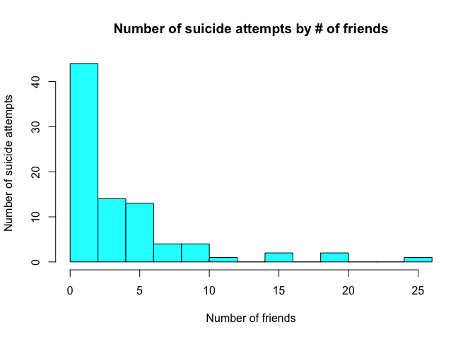

```r
SuicideFriends <- subset(ForeverAlone, attempt_suicide == "Yes", friends)
hist(SuicideFriends$friends, main = "Number of suicide attempts by # of friends",
     xlab ="Number of friends",
     ylab = "Number of suicide attempts",
     col = "cyan", breaks="FD")
```

[figure not shown]

```r
rate <- 0.2652106
hist(SuicideFriends$friends, main = "Age of those who attempted suicide w/ probability",
     xlab ="Age of suicide",
     col = "cyan",
     probability = TRUE, breaks="FD")
curve(dexp(x, rate = rate), add=TRUE, col="red")
```

```r
breaks <- hist(SuicideFriends$friends, breaks="FD")$breaks
observed <- hist(SuicideFriends$friends, breaks="FD")$count
```

```r
observed[4] <- sum(observed[4:5])
observed[5] <- sum(observed[6:13])
observed <- observed[-(6:13)]
numOfObservations <- sum(observed)
expected <- numOfObservations*c(pexp(2, rate),
                                pexp(4, rate)-pexp(2, rate),
                                pexp(6, rate)-pexp(4, rate),
                                pexp(10, rate)-pexp(6, rate),
                                1-pexp(10, rate))
Chi2 <-sum((observed-expected)^2/expected); Chi2 # 5.465886

# Since we have our expected total equal to actual equal
# and imposed the rate parameter, the df is 5-1-1 = 3
Pvalue <- pchisq(Chi2,3,lower.tail = FALSE); Pvalue # 0.1406933
```

This means that there is 14% chance that this result happens as a exponential distribution. With this value, there is not enough evidence against the null hypothesis that our data did come from a exponential distribution.

## Friends and Suicide: finding correlation using permutation test (simulation method)

Let’s see if through permutation test, whether or not number of friends has relation to whether or not to attempt suicide. Note that in order to come up with a proper normal distribution, because this data has a strong positive skew, I would need to trim the data. Find if there is a p-value that is <=5% if skewness is between -1 and 1.

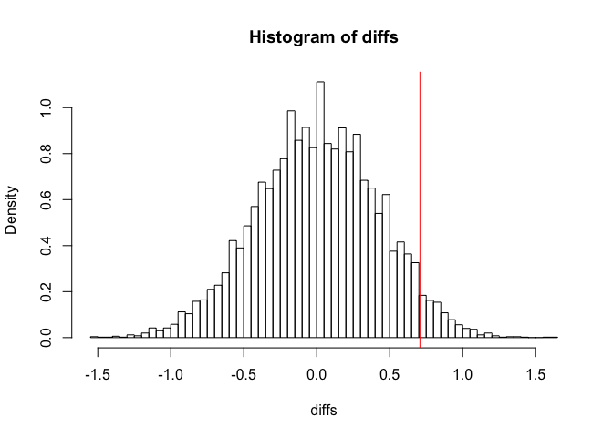

```r
# function to trim dataset based on a percentage
trimFriendData <- function (data, percentage) {
  newData <- data

  upper_quantile <- quantile(newData$friends, 1-percentage)
  lower_quantile <- quantile(newData$friends, percentage)

  newData$friends[newData$friends > upper_quantile] <- NA
  newData$friends[newData$friends < lower_quantile] <- NA

  subset(newData, !is.na(friends))
}

findPValueWithTrimmedFriends <- function (percentage) {
  ForeverAlone.Trimmed <- trimFriendData(ForeverAlone, percentage)

  cat("This is the trimmed mean = ", mean(ForeverAlone.Trimmed$friends), " \n")
  cat("This is the skewness for your trimmed subset = ", skewness(ForeverAlone.Trimmed$friends), "\n")

  # Now let's redo the permutation test with this new table
  AttemptedFriendNumAvg <- mean(ForeverAlone.Trimmed$friends[which(ForeverAlone.Trimmed$attempt_suicide == "Yes")])
  NotAttemptedFriendNumAvg <- mean(ForeverAlone.Trimmed$friends[which(ForeverAlone.Trimmed$attempt_suicide == "No")])
  observed <- NotAttemptedFriendNumAvg - AttemptedFriendNumAvg; observed

  # let's see if through permutation test, whether or not number of friends has relation to whether or not to attempt suicide
  N <- 10000
  diffs <- numeric(N)
  for (i in 1:N){
    Attempted <- sample(ForeverAlone.Trimmed$attempt_suicide)   # permuted suicide attempt column
    AttemptedFriendNumAvg <- mean(ForeverAlone.Trimmed$friends[which(Attempted == 'Yes')])
    NotAttemptedFriendNumAvg <- mean(ForeverAlone.Trimmed$friends[which(Attempted == 'No')])
    diffs[i] <- NotAttemptedFriendNumAvg - AttemptedFriendNumAvg
  }

  hist(diffs, breaks = "FD", probability = TRUE) # BEAUTIFUL! It looks like a proper normal distribution :)
  abline(v = observed, col = "red")

  pvalue <- (sum(diffs >= observed)+1)/(N+1)
  cat("This is your p-value = ", pvalue, "\n")
}

# test out numbers, see which one is has low skewness and see if the p-value can still be statistically significant
# after a couple of tries with many numbers... found that `0.11` is the sweetspot to keep
# the skewness low but find a statistically significant subset.

findPValueWithTrimmedFriends(0.11)
```

Found that with trimming the data at 0.11, the trimmed mean = `3.390168`, skewness = `0.9407331` and p-value = `0.04479552`. If we define statistical significance as p-value <= 0.05), do reject that having friends and suicide attempt are independent. And even after making data not have a high skewness level (between -1 and 1), they are actually statistically significant!

## Friends and Suicide: Logical Regression

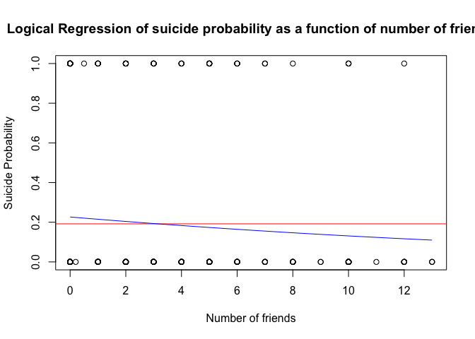

```r
getLogicalRegressionValues <- function (percentage) {
  ForeverAlone.Trimmed <- trimFriendData(ForeverAlone, percentage)

  cat("This is the skewness for your trimmed subset = ", skewness(ForeverAlone.Trimmed$friends), "\n")

  # Let's try to see if using logistic regression can make it seem like it is statistical significant
  attemptedSuicide <- (as.numeric(ForeverAlone.Trimmed$attempt_suicide=="Yes")); head(attemptedSuicide)

  friends <- ForeverAlone.Trimmed$friends
  plot(friends, attemptedSuicide, xlab="Number of friends", ylab="Suicide Probability", main = "Logical Regression of suicide probability as a function of number of friends")
  b <- cov(friends, attemptedSuicide)/var(income) # obtain slope
  # Find the intercept
  a <- mean(attemptedSuicide) - b*mean(friends);a
  #We can add this regression line to the plot of the data
  abline(a, b, col = "red")

  MLL<- function(alpha, beta) {
    -sum( log( exp(alpha+beta*friends)/(1+exp(alpha+beta*friends)) )*attemptedSuicide +
            log(1/(1+exp(alpha+beta*friends)))*(1-attemptedSuicide) )
  }

  #R has a function that will maximize this function of alpha and beta
  results<-mle(MLL, start = list(alpha = 0, beta = 0)) #an initial guess is required
  results@coef
  curve( exp(results@coef[1]+results@coef[2]*x)/ (1+exp(results@coef[1]+results@coef[2]*x)),col = "blue", add=TRUE)
  # shows slight decline as number of friends grow

  # test for all the income values to see if it is a good model
  uniqueNumOfFriends <- sort(unique(friends))
  findMean <- function (numOfFriendsToEvaluate) {
    index <- which(friends == numOfFriendsToEvaluate); head(index)
    mean(attemptedSuicide[index])   #20%
  }

  res <- lapply(uniqueNumOfFriends, findMean)
  cleanRes <- numeric(length(res))
  for (idx in 1: length(res)) {
    cleanRes[idx] = res[[idx]]
  }
  cleanRes

  data.frame(number_of_friends = uniqueNumOfFriends, mean_attempted_suicide=cleanRes)
}

regressionWithThreshold <- getLogicalRegressionValues(0.11);
```

It’s strange because this logical regression value fluctuates a lot in this subset. But apparently it is statistically significant? Surprise!?